# Risk Factor Analysis

## Outcome Variable

**Outcome Variable:** ever_stunted

## Predictor Variables

**Intervention Variable:** hdlvry

**Adjustment Set:**

- arm
- W_mage
- meducyrs
- feducyrs
- hhwealth_quart
- single
- W_nrooms
- brthmon
- W_parity
- impsan
- delta_W_mage
- delta_meducyrs
- delta_feducyrs
- delta_hhwealth_quart
- delta_single
- delta_W_nrooms
- delta_brthmon
- delta_W_parity
- delta_impsan

## Stratifying Variables

The analysis was stratified on these variable(s):

- agecat
- studyid
- country

## Data Summary

| agecat | studyid | country | hdlvry | ever_stunted | n_cell | n |
| --- | --- | --- | --- | --- | --- | --- |
| 0-24 months (no birth st.) | CMC-V-BCS-2002 | INDIA | 0 | 0 | 27 | 293 |
| 0-24 months (no birth st.) | CMC-V-BCS-2002 | INDIA | 0 | 1 | 260 | 293 |
| 0-24 months (no birth st.) | CMC-V-BCS-2002 | INDIA | 1 | 0 | 1 | 293 |
| 0-24 months (no birth st.) | CMC-V-BCS-2002 | INDIA | 1 | 1 | 5 | 293 |
| 0-24 months (no birth st.) | COHORTS | INDIA | 0 | 0 | 2102 | 4479 |
| 0-24 months (no birth st.) | COHORTS | INDIA | 0 | 1 | 686 | 4479 |
| 0-24 months (no birth st.) | COHORTS | INDIA | 1 | 0 | 1017 | 4479 |
| 0-24 months (no birth st.) | COHORTS | INDIA | 1 | 1 | 674 | 4479 |
| 0-24 months (no birth st.) | EE | PAKISTAN | 0 | 0 | 29 | 212 |
| 0-24 months (no birth st.) | EE | PAKISTAN | 0 | 1 | 112 | 212 |
| 0-24 months (no birth st.) | EE | PAKISTAN | 1 | 0 | 12 | 212 |
| 0-24 months (no birth st.) | EE | PAKISTAN | 1 | 1 | 59 | 212 |
| 0-24 months (no birth st.) | GMS-Nepal | NEPAL | 0 | 0 | 66 | 535 |
| 0-24 months (no birth st.) | GMS-Nepal | NEPAL | 0 | 1 | 61 | 535 |
| 0-24 months (no birth st.) | GMS-Nepal | NEPAL | 1 | 0 | 168 | 535 |
| 0-24 months (no birth st.) | GMS-Nepal | NEPAL | 1 | 1 | 240 | 535 |
| 0-24 months (no birth st.) | IRC | INDIA | 0 | 0 | 145 | 360 |
| 0-24 months (no birth st.) | IRC | INDIA | 0 | 1 | 208 | 360 |
| 0-24 months (no birth st.) | IRC | INDIA | 1 | 0 | 2 | 360 |
| 0-24 months (no birth st.) | IRC | INDIA | 1 | 1 | 5 | 360 |
| 0-24 months (no birth st.) | JiVitA-3 | BANGLADESH | 0 | 0 | 25 | 259 |
| 0-24 months (no birth st.) | JiVitA-3 | BANGLADESH | 0 | 1 | 9 | 259 |
| 0-24 months (no birth st.) | JiVitA-3 | BANGLADESH | 1 | 0 | 137 | 259 |
| 0-24 months (no birth st.) | JiVitA-3 | BANGLADESH | 1 | 1 | 88 | 259 |
| 0-24 months (no birth st.) | JiVitA-4 | BANGLADESH | 0 | 0 | 541 | 3194 |
| 0-24 months (no birth st.) | JiVitA-4 | BANGLADESH | 0 | 1 | 339 | 3194 |
| 0-24 months (no birth st.) | JiVitA-4 | BANGLADESH | 1 | 0 | 1288 | 3194 |
| 0-24 months (no birth st.) | JiVitA-4 | BANGLADESH | 1 | 1 | 1026 | 3194 |
| 0-24 months (no birth st.) | NIH-Crypto | BANGLADESH | 0 | 0 | 320 | 653 |
| 0-24 months (no birth st.) | NIH-Crypto | BANGLADESH | 0 | 1 | 194 | 653 |

[output cut: 114 more lines]

The following strata were considered:

- agecat: 0-24 months (no birth st.), studyid: CMC-V-BCS-2002, country: INDIA
- agecat: 0-24 months (no birth st.), studyid: COHORTS, country: INDIA
- agecat: 0-24 months (no birth st.), studyid: EE, country: PAKISTAN
- agecat: 0-24 months (no birth st.), studyid: GMS-Nepal, country: NEPAL
- agecat: 0-24 months (no birth st.), studyid: IRC, country: INDIA
- agecat: 0-24 months (no birth st.), studyid: JiVitA-3, country: BANGLADESH
- agecat: 0-24 months (no birth st.), studyid: JiVitA-4, country: BANGLADESH
- agecat: 0-24 months (no birth st.), studyid: NIH-Crypto, country: BANGLADESH
- agecat: 0-24 months (no birth st.), studyid: PROVIDE, country: BANGLADESH
- agecat: 0-24 months (no birth st.), studyid: SAS-CompFeed, country: INDIA
- agecat: 0-24 months (no birth st.), studyid: SAS-FoodSuppl, country: INDIA
- agecat: 0-24 months (no birth st.), studyid: TanzaniaChild2, country: TANZANIA, UNITED REPUBLIC OF
- agecat: 0-6 months (no birth st.), studyid: CMC-V-BCS-2002, country: INDIA
- agecat: 0-6 months (no birth st.), studyid: COHORTS, country: INDIA
- agecat: 0-6 months (no birth st.), studyid: EE, country: PAKISTAN
- agecat: 0-6 months (no birth st.), studyid: GMS-Nepal, country: NEPAL
- agecat: 0-6 months (no birth st.), studyid: IRC, country: INDIA
- agecat: 0-6 months (no birth st.), studyid: JiVitA-3, country: BANGLADESH
- agecat: 0-6 months (no birth st.), studyid: JiVitA-4, country: BANGLADESH
- agecat: 0-6 months (no birth st.), studyid: NIH-Crypto, country: BANGLADESH
- agecat: 0-6 months (no birth st.), studyid: PROVIDE, country: BANGLADESH
- agecat: 0-6 months (no birth st.), studyid: SAS-CompFeed, country: INDIA
- agecat: 0-6 months (no birth st.), studyid: SAS-FoodSuppl, country: INDIA
- agecat: 0-6 months (no birth st.), studyid: TanzaniaChild2, country: TANZANIA, UNITED REPUBLIC OF
- agecat: 6-24 months, studyid: CMC-V-BCS-2002, country: INDIA
- agecat: 6-24 months, studyid: COHORTS, country: INDIA
- agecat: 6-24 months, studyid: EE, country: PAKISTAN
- agecat: 6-24 months, studyid: GMS-Nepal, country: NEPAL
- agecat: 6-24 months, studyid: IRC, country: INDIA
- agecat: 6-24 months, studyid: JiVitA-3, country: BANGLADESH
- agecat: 6-24 months, studyid: JiVitA-4, country: BANGLADESH
- agecat: 6-24 months, studyid: NIH-Crypto, country: BANGLADESH
- agecat: 6-24 months, studyid: PROVIDE, country: BANGLADESH
- agecat: 6-24 months, studyid: SAS-CompFeed, country: INDIA
- agecat: 6-24 months, studyid: SAS-FoodSuppl, country: INDIA
- agecat: 6-24 months, studyid: TanzaniaChild2, country: TANZANIA, UNITED REPUBLIC OF

### Dropped Strata

Some strata were dropped due to rare outcomes:

- agecat: 0-24 months (no birth st.), studyid: CMC-V-BCS-2002, country: INDIA
- agecat: 0-24 months (no birth st.), studyid: IRC, country: INDIA
- agecat: 0-6 months (no birth st.), studyid: CMC-V-BCS-2002, country: INDIA
- agecat: 0-6 months (no birth st.), studyid: IRC, country: INDIA
- agecat: 0-6 months (no birth st.), studyid: JiVitA-3, country: BANGLADESH
- agecat: 0-6 months (no birth st.), studyid: SAS-FoodSuppl, country: INDIA
- agecat: 6-24 months, studyid: CMC-V-BCS-2002, country: INDIA
- agecat: 6-24 months, studyid: IRC, country: INDIA

## Methods Detail

We’re interested in the causal parameters $E[Y_a]$ for all values of $a \in \mathcal{A}$. These parameters represent the mean outcome if, possibly contrary to fact, we intervened to set all units to have $A=a$. Under the randomization and positivity assumptions, these are identified by the statistical parameters $\psi_a=E_W[E_{Y|A,W}(Y|A=a,W)]$. In addition, we’re interested in the mean of $Y$, $E[Y]$ under no intervention (the observed mean). We will estimate these parameters by using SuperLearner to fit the relevant likelihood factors – $E_{Y|A,W}(Y|A=a,W)$ and $p(A=a|W)$, and then updating our likelihood fit using a joint TMLE.

For unadjusted analyses ($W=\{\}$), initial likelihoods were estimated using Lrnr_glm to estimate the simple $E(Y|A)$ and Lrnr_mean to estimate $p(A)$. For adjusted analyses, a small library containing Lrnr_glmnet, Lrnr_xgboost, and Lrnr_mean was used.

Having estimated these parameters, we will then use the delta method to estimate relative risks and attributable risks relative to a prespecified baseline level of $A$.

# Results Detail

## Results Plots

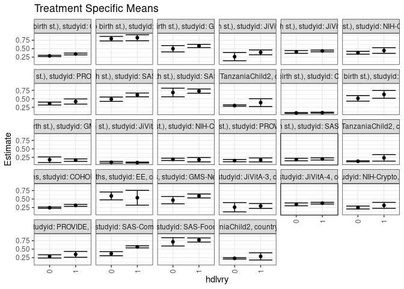

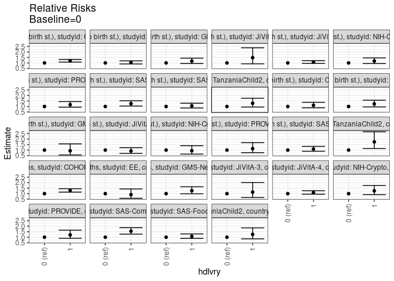

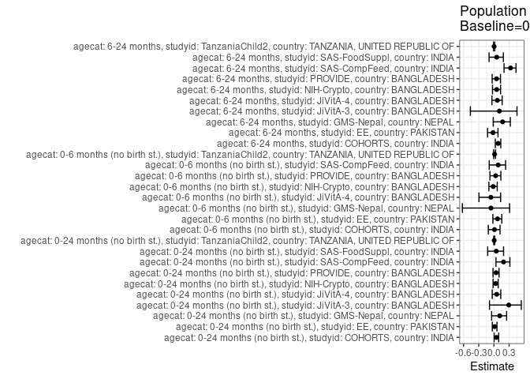

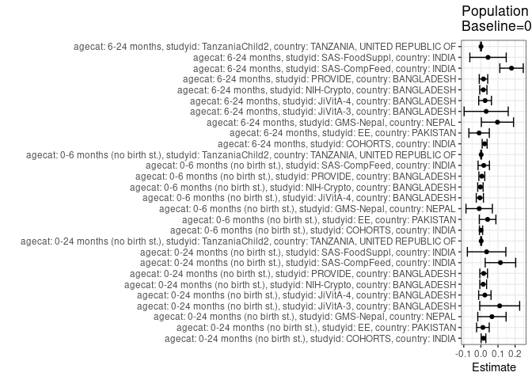

## Results Table

### Parameter: TSM

| agecat | studyid | country | intervention_level | baseline_level | estimate | ci_lower | ci_upper |
| --- | --- | --- | --- | --- | --- | --- | --- |
| 0-24 months (no birth st.) | COHORTS | INDIA | 0 | NA | 0.2882799 | 0.2693409 | 0.3072190 |
| 0-24 months (no birth st.) | COHORTS | INDIA | 1 | NA | 0.3433687 | 0.3169775 | 0.3697599 |
| 0-24 months (no birth st.) | EE | PAKISTAN | 0 | NA | 0.7947297 | 0.7278363 | 0.8616231 |
| 0-24 months (no birth st.) | EE | PAKISTAN | 1 | NA | 0.8232156 | 0.7343084 | 0.9121227 |
| 0-24 months (no birth st.) | GMS-Nepal | NEPAL | 0 | NA | 0.4980080 | 0.4042984 | 0.5917175 |
| 0-24 months (no birth st.) | GMS-Nepal | NEPAL | 1 | NA | 0.5801537 | 0.5321858 | 0.6281216 |
| 0-24 months (no birth st.) | JiVitA-3 | BANGLADESH | 0 | NA | 0.2647059 | 0.1432986 | 0.3861132 |
| 0-24 months (no birth st.) | JiVitA-3 | BANGLADESH | 1 | NA | 0.3911111 | 0.3201765 | 0.4620457 |
| 0-24 months (no birth st.) | JiVitA-4 | BANGLADESH | 0 | NA | 0.4040780 | 0.3631353 | 0.4450206 |
| 0-24 months (no birth st.) | JiVitA-4 | BANGLADESH | 1 | NA | 0.4335032 | 0.4086310 | 0.4583753 |
| 0-24 months (no birth st.) | NIH-Crypto | BANGLADESH | 0 | NA | 0.3798505 | 0.3379676 | 0.4217334 |
| 0-24 months (no birth st.) | NIH-Crypto | BANGLADESH | 1 | NA | 0.4456327 | 0.3624083 | 0.5288571 |
| 0-24 months (no birth st.) | PROVIDE | BANGLADESH | 0 | NA | 0.3596943 | 0.3162704 | 0.4031181 |
| 0-24 months (no birth st.) | PROVIDE | BANGLADESH | 1 | NA | 0.4193629 | 0.3433721 | 0.4953537 |
| 0-24 months (no birth st.) | SAS-CompFeed | INDIA | 0 | NA | 0.4877764 | 0.4242394 | 0.5513133 |
| 0-24 months (no birth st.) | SAS-CompFeed | INDIA | 1 | NA | 0.6144750 | 0.5582987 | 0.6706514 |
| 0-24 months (no birth st.) | SAS-FoodSuppl | INDIA | 0 | NA | 0.6863880 | 0.5592973 | 0.8134788 |
| 0-24 months (no birth st.) | SAS-FoodSuppl | INDIA | 1 | NA | 0.7276479 | 0.6650820 | 0.7902137 |
| 0-24 months (no birth st.) | TanzaniaChild2 | TANZANIA, UNITED REPUBLIC OF | 0 | NA | 0.2993610 | 0.2795822 | 0.3191398 |
| 0-24 months (no birth st.) | TanzaniaChild2 | TANZANIA, UNITED REPUBLIC OF | 1 | NA | 0.3868282 | 0.2715399 | 0.5021166 |
| 0-6 months (no birth st.) | COHORTS | INDIA | 0 | NA | 0.0803192 | 0.0678901 | 0.0927483 |
| 0-6 months (no birth st.) | COHORTS | INDIA | 1 | NA | 0.0887477 | 0.0741344 | 0.1033610 |
| 0-6 months (no birth st.) | EE | PAKISTAN | 0 | NA | 0.5125682 | 0.4299942 | 0.5951421 |
| 0-6 months (no birth st.) | EE | PAKISTAN | 1 | NA | 0.6305943 | 0.5164354 | 0.7447532 |
| 0-6 months (no birth st.) | GMS-Nepal | NEPAL | 0 | NA | 0.1800320 | 0.0961910 | 0.2638731 |
| 0-6 months (no birth st.) | GMS-Nepal | NEPAL | 1 | NA | 0.1684601 | 0.1320466 | 0.2048736 |
| 0-6 months (no birth st.) | JiVitA-4 | BANGLADESH | 0 | NA | 0.1038462 | 0.0788638 | 0.1288286 |
| 0-6 months (no birth st.) | JiVitA-4 | BANGLADESH | 1 | NA | 0.0955833 | 0.0812734 | 0.1098932 |
| 0-6 months (no birth st.) | NIH-Crypto | BANGLADESH | 0 | NA | 0.1925934 | 0.1584471 | 0.2267398 |
| 0-6 months (no birth st.) | NIH-Crypto | BANGLADESH | 1 | NA | 0.1815470 | 0.1170922 | 0.2460018 |
| 0-6 months (no birth st.) | PROVIDE | BANGLADESH | 0 | NA | 0.1540323 | 0.1213119 | 0.1867527 |
| 0-6 months (no birth st.) | PROVIDE | BANGLADESH | 1 | NA | 0.1743689 | 0.1160065 | 0.2327313 |
| 0-6 months (no birth st.) | SAS-CompFeed | INDIA | 0 | NA | 0.1860444 | 0.1491863 | 0.2229025 |
| 0-6 months (no birth st.) | SAS-CompFeed | INDIA | 1 | NA | 0.2030385 | 0.1718456 | 0.2342315 |
| 0-6 months (no birth st.) | TanzaniaChild2 | TANZANIA, UNITED REPUBLIC OF | 0 | NA | 0.1358202 | 0.1210246 | 0.1506157 |
| 0-6 months (no birth st.) | TanzaniaChild2 | TANZANIA, UNITED REPUBLIC OF | 1 | NA | 0.2368421 | 0.1403120 | 0.3333722 |
| 6-24 months | COHORTS | INDIA | 0 | NA | 0.2441103 | 0.2246292 | 0.2635915 |
| 6-24 months | COHORTS | INDIA | 1 | NA | 0.3127756 | 0.2844856 | 0.3410657 |
| 6-24 months | EE | PAKISTAN | 0 | NA | 0.5909615 | 0.4745091 | 0.7074139 |
| 6-24 months | EE | PAKISTAN | 1 | NA | 0.5375062 | 0.3196643 | 0.7553481 |
| 6-24 months | GMS-Nepal | NEPAL | 0 | NA | 0.4661304 | 0.3588042 | 0.5734566 |
| 6-24 months | GMS-Nepal | NEPAL | 1 | NA | 0.5909995 | 0.5334932 | 0.6485057 |
| 6-24 months | JiVitA-3 | BANGLADESH | 0 | NA | 0.2580645 | 0.1217194 | 0.3944096 |
| 6-24 months | JiVitA-3 | BANGLADESH | 1 | NA | 0.2941176 | 0.2209212 | 0.3673141 |
| 6-24 months | JiVitA-4 | BANGLADESH | 0 | NA | 0.3429183 | 0.3007034 | 0.3851331 |
| 6-24 months | JiVitA-4 | BANGLADESH | 1 | NA | 0.3766746 | 0.3512773 | 0.4020718 |
| 6-24 months | NIH-Crypto | BANGLADESH | 0 | NA | 0.2484433 | 0.2060734 | 0.2908132 |
| 6-24 months | NIH-Crypto | BANGLADESH | 1 | NA | 0.3123342 | 0.2246618 | 0.4000067 |
| 6-24 months | PROVIDE | BANGLADESH | 0 | NA | 0.2851944 | 0.2372624 | 0.3331265 |
| 6-24 months | PROVIDE | BANGLADESH | 1 | NA | 0.3457888 | 0.2592050 | 0.4323726 |
| 6-24 months | SAS-CompFeed | INDIA | 0 | NA | 0.3661263 | 0.3055360 | 0.4267167 |
| 6-24 months | SAS-CompFeed | INDIA | 1 | NA | 0.5676153 | 0.5381617 | 0.5970690 |
| 6-24 months | SAS-FoodSuppl | INDIA | 0 | NA | 0.7154019 | 0.5928623 | 0.8379414 |
| 6-24 months | SAS-FoodSuppl | INDIA | 1 | NA | 0.7700345 | 0.7093051 | 0.8307640 |
| 6-24 months | TanzaniaChild2 | TANZANIA, UNITED REPUBLIC OF | 0 | NA | 0.2273936 | 0.2059594 | 0.2488279 |
| 6-24 months | TanzaniaChild2 | TANZANIA, UNITED REPUBLIC OF | 1 | NA | 0.2857143 | 0.1792529 | 0.3921757 |

### Parameter: E(Y)

| agecat | studyid | country | intervention_level | baseline_level | estimate | ci_lower | ci_upper |
| --- | --- | --- | --- | --- | --- | --- | --- |
| 0-24 months (no birth st.) | COHORTS | INDIA | NA | NA | 0.3036392 | 0.2901712 | 0.3171072 |
| 0-24 months (no birth st.) | EE | PAKISTAN | NA | NA | 0.8066038 | 0.7533119 | 0.8598956 |
| 0-24 months (no birth st.) | GMS-Nepal | NEPAL | NA | NA | 0.5626168 | 0.5205427 | 0.6046909 |
| 0-24 months (no birth st.) | JiVitA-3 | BANGLADESH | NA | NA | 0.3745174 | 0.3090067 | 0.4400281 |
| 0-24 months (no birth st.) | JiVitA-4 | BANGLADESH | NA | NA | 0.4273638 | 0.4069167 | 0.4478110 |
| 0-24 months (no birth st.) | NIH-Crypto | BANGLADESH | NA | NA | 0.3935681 | 0.3560687 | 0.4310676 |
| 0-24 months (no birth st.) | PROVIDE | BANGLADESH | NA | NA | 0.3759874 | 0.3382238 | 0.4137509 |
| 0-24 months (no birth st.) | SAS-CompFeed | INDIA | NA | NA | 0.6020293 | 0.5512634 | 0.6527952 |
| 0-24 months (no birth st.) | SAS-FoodSuppl | INDIA | NA | NA | 0.7198444 | 0.6648337 | 0.7748550 |
| 0-24 months (no birth st.) | TanzaniaChild2 | TANZANIA, UNITED REPUBLIC OF | NA | NA | 0.3010803 | 0.2815901 | 0.3205706 |
| 0-6 months (no birth st.) | COHORTS | INDIA | NA | NA | 0.0812729 | 0.0731685 | 0.0893773 |
| 0-6 months (no birth st.) | EE | PAKISTAN | NA | NA | 0.5518868 | 0.4847863 | 0.6189873 |
| 0-6 months (no birth st.) | GMS-Nepal | NEPAL | NA | NA | 0.1700935 | 0.1382268 | 0.2019601 |
| 0-6 months (no birth st.) | JiVitA-4 | BANGLADESH | NA | NA | 0.0979284 | 0.0852731 | 0.1105838 |
| 0-6 months (no birth st.) | NIH-Crypto | BANGLADESH | NA | NA | 0.1898928 | 0.1597870 | 0.2199986 |
| 0-6 months (no birth st.) | PROVIDE | BANGLADESH | NA | NA | 0.1595577 | 0.1310079 | 0.1881074 |
| 0-6 months (no birth st.) | SAS-CompFeed | INDIA | NA | NA | 0.2029312 | 0.1748514 | 0.2310111 |
| 0-6 months (no birth st.) | TanzaniaChild2 | TANZANIA, UNITED REPUBLIC OF | NA | NA | 0.1376233 | 0.1229861 | 0.1522605 |
| 6-24 months | COHORTS | INDIA | NA | NA | 0.2661332 | 0.2522150 | 0.2800514 |
| 6-24 months | EE | PAKISTAN | NA | NA | 0.5806452 | 0.4798127 | 0.6814776 |
| 6-24 months | GMS-Nepal | NEPAL | NA | NA | 0.5630027 | 0.5125980 | 0.6134074 |
| 6-24 months | JiVitA-3 | BANGLADESH | NA | NA | 0.2889908 | 0.2220207 | 0.3559610 |
| 6-24 months | JiVitA-4 | BANGLADESH | NA | NA | 0.3675807 | 0.3466082 | 0.3885532 |
| 6-24 months | NIH-Crypto | BANGLADESH | NA | NA | 0.2628458 | 0.2244546 | 0.3012371 |
| 6-24 months | PROVIDE | BANGLADESH | NA | NA | 0.3004386 | 0.2583143 | 0.3425629 |
| 6-24 months | SAS-CompFeed | INDIA | NA | NA | 0.5451761 | 0.5131549 | 0.5771973 |
| 6-24 months | SAS-FoodSuppl | INDIA | NA | NA | 0.7572016 | 0.7031798 | 0.8112234 |
| 6-24 months | TanzaniaChild2 | TANZANIA, UNITED REPUBLIC OF | NA | NA | 0.2281967 | 0.2071268 | 0.2492667 |

### Parameter: RR

| agecat | studyid | country | intervention_level | baseline_level | estimate | ci_lower | ci_upper |
| --- | --- | --- | --- | --- | --- | --- | --- |
| 0-24 months (no birth st.) | COHORTS | INDIA | 0 | 0 | 1.0000000 | 1.0000000 | 1.000000 |
| 0-24 months (no birth st.) | COHORTS | INDIA | 1 | 0 | 1.1910947 | 1.0777423 | 1.316369 |
| 0-24 months (no birth st.) | EE | PAKISTAN | 0 | 0 | 1.0000000 | 1.0000000 | 1.000000 |
| 0-24 months (no birth st.) | EE | PAKISTAN | 1 | 0 | 1.0358435 | 0.9029625 | 1.188279 |
| 0-24 months (no birth st.) | GMS-Nepal | NEPAL | 0 | 0 | 1.0000000 | 1.0000000 | 1.000000 |
| 0-24 months (no birth st.) | GMS-Nepal | NEPAL | 1 | 0 | 1.1649486 | 0.9480996 | 1.431395 |
| 0-24 months (no birth st.) | JiVitA-3 | BANGLADESH | 0 | 0 | 1.0000000 | 1.0000000 | 1.000000 |
| 0-24 months (no birth st.) | JiVitA-3 | BANGLADESH | 1 | 0 | 1.4775309 | 0.9188173 | 2.375986 |
| 0-24 months (no birth st.) | JiVitA-4 | BANGLADESH | 0 | 0 | 1.0000000 | 1.0000000 | 1.000000 |
| 0-24 months (no birth st.) | JiVitA-4 | BANGLADESH | 1 | 0 | 1.0728206 | 0.9538012 | 1.206692 |
| 0-24 months (no birth st.) | NIH-Crypto | BANGLADESH | 0 | 0 | 1.0000000 | 1.0000000 | 1.000000 |
| 0-24 months (no birth st.) | NIH-Crypto | BANGLADESH | 1 | 0 | 1.1731792 | 0.9455054 | 1.455676 |
| 0-24 months (no birth st.) | PROVIDE | BANGLADESH | 0 | 0 | 1.0000000 | 1.0000000 | 1.000000 |
| 0-24 months (no birth st.) | PROVIDE | BANGLADESH | 1 | 0 | 1.1658871 | 0.9394813 | 1.446854 |
| 0-24 months (no birth st.) | SAS-CompFeed | INDIA | 0 | 0 | 1.0000000 | 1.0000000 | 1.000000 |
| 0-24 months (no birth st.) | SAS-CompFeed | INDIA | 1 | 0 | 1.2597474 | 1.0435404 | 1.520749 |
| 0-24 months (no birth st.) | SAS-FoodSuppl | INDIA | 0 | 0 | 1.0000000 | 1.0000000 | 1.000000 |
| 0-24 months (no birth st.) | SAS-FoodSuppl | INDIA | 1 | 0 | 1.0601115 | 0.8640985 | 1.300588 |
| 0-24 months (no birth st.) | TanzaniaChild2 | TANZANIA, UNITED REPUBLIC OF | 0 | 0 | 1.0000000 | 1.0000000 | 1.000000 |
| 0-24 months (no birth st.) | TanzaniaChild2 | TANZANIA, UNITED REPUBLIC OF | 1 | 0 | 1.2921798 | 0.9522844 | 1.753393 |
| 0-6 months (no birth st.) | COHORTS | INDIA | 0 | 0 | 1.0000000 | 1.0000000 | 1.000000 |
| 0-6 months (no birth st.) | COHORTS | INDIA | 1 | 0 | 1.1049382 | 0.8820314 | 1.384178 |
| 0-6 months (no birth st.) | EE | PAKISTAN | 0 | 0 | 1.0000000 | 1.0000000 | 1.000000 |
| 0-6 months (no birth st.) | EE | PAKISTAN | 1 | 0 | 1.2302643 | 0.9632177 | 1.571348 |
| 0-6 months (no birth st.) | GMS-Nepal | NEPAL | 0 | 0 | 1.0000000 | 1.0000000 | 1.000000 |
| 0-6 months (no birth st.) | GMS-Nepal | NEPAL | 1 | 0 | 0.9357230 | 0.5598324 | 1.563999 |
| 0-6 months (no birth st.) | JiVitA-4 | BANGLADESH | 0 | 0 | 1.0000000 | 1.0000000 | 1.000000 |
| 0-6 months (no birth st.) | JiVitA-4 | BANGLADESH | 1 | 0 | 0.9204310 | 0.6982095 | 1.213380 |
| 0-6 months (no birth st.) | NIH-Crypto | BANGLADESH | 0 | 0 | 1.0000000 | 1.0000000 | 1.000000 |
| 0-6 months (no birth st.) | NIH-Crypto | BANGLADESH | 1 | 0 | 0.9426438 | 0.6342465 | 1.400997 |
| 0-6 months (no birth st.) | PROVIDE | BANGLADESH | 0 | 0 | 1.0000000 | 1.0000000 | 1.000000 |
| 0-6 months (no birth st.) | PROVIDE | BANGLADESH | 1 | 0 | 1.1320279 | 0.7637628 | 1.677860 |
| 0-6 months (no birth st.) | SAS-CompFeed | INDIA | 0 | 0 | 1.0000000 | 1.0000000 | 1.000000 |
| 0-6 months (no birth st.) | SAS-CompFeed | INDIA | 1 | 0 | 1.0913447 | 0.8933411 | 1.333235 |
| 0-6 months (no birth st.) | TanzaniaChild2 | TANZANIA, UNITED REPUBLIC OF | 0 | 0 | 1.0000000 | 1.0000000 | 1.000000 |
| 0-6 months (no birth st.) | TanzaniaChild2 | TANZANIA, UNITED REPUBLIC OF | 1 | 0 | 1.7437917 | 1.1436025 | 2.658974 |
| 6-24 months | COHORTS | INDIA | 0 | 0 | 1.0000000 | 1.0000000 | 1.000000 |
| 6-24 months | COHORTS | INDIA | 1 | 0 | 1.2812878 | 1.1368055 | 1.444133 |
| 6-24 months | EE | PAKISTAN | 0 | 0 | 1.0000000 | 1.0000000 | 1.000000 |
| 6-24 months | EE | PAKISTAN | 1 | 0 | 0.9095451 | 0.5804158 | 1.425310 |
| 6-24 months | GMS-Nepal | NEPAL | 0 | 0 | 1.0000000 | 1.0000000 | 1.000000 |
| 6-24 months | GMS-Nepal | NEPAL | 1 | 0 | 1.2678844 | 0.9871875 | 1.628395 |
| 6-24 months | JiVitA-3 | BANGLADESH | 0 | 0 | 1.0000000 | 1.0000000 | 1.000000 |
| 6-24 months | JiVitA-3 | BANGLADESH | 1 | 0 | 1.1397059 | 0.6462995 | 2.009795 |
| 6-24 months | JiVitA-4 | BANGLADESH | 0 | 0 | 1.0000000 | 1.0000000 | 1.000000 |
| 6-24 months | JiVitA-4 | BANGLADESH | 1 | 0 | 1.0984384 | 0.9529343 | 1.266160 |
| 6-24 months | NIH-Crypto | BANGLADESH | 0 | 0 | 1.0000000 | 1.0000000 | 1.000000 |
| 6-24 months | NIH-Crypto | BANGLADESH | 1 | 0 | 1.2571648 | 0.9075171 | 1.741525 |
| 6-24 months | PROVIDE | BANGLADESH | 0 | 0 | 1.0000000 | 1.0000000 | 1.000000 |
| 6-24 months | PROVIDE | BANGLADESH | 1 | 0 | 1.2124668 | 0.8987012 | 1.635778 |
| 6-24 months | SAS-CompFeed | INDIA | 0 | 0 | 1.0000000 | 1.0000000 | 1.000000 |
| 6-24 months | SAS-CompFeed | INDIA | 1 | 0 | 1.5503265 | 1.2832237 | 1.873027 |
| 6-24 months | SAS-FoodSuppl | INDIA | 0 | 0 | 1.0000000 | 1.0000000 | 1.000000 |
| 6-24 months | SAS-FoodSuppl | INDIA | 1 | 0 | 1.0763664 | 0.8912946 | 1.299867 |
| 6-24 months | TanzaniaChild2 | TANZANIA, UNITED REPUBLIC OF | 0 | 0 | 1.0000000 | 1.0000000 | 1.000000 |
| 6-24 months | TanzaniaChild2 | TANZANIA, UNITED REPUBLIC OF | 1 | 0 | 1.2564745 | 0.8555225 | 1.845338 |

### Parameter: PAR

| agecat | studyid | country | intervention_level | baseline_level | estimate | ci_lower | ci_upper |
| --- | --- | --- | --- | --- | --- | --- | --- |
| 0-24 months (no birth st.) | COHORTS | INDIA | 0 | NA | 0.0153593 | 0.0016803 | 0.0290382 |
| 0-24 months (no birth st.) | EE | PAKISTAN | 0 | NA | 0.0118741 | -0.0249803 | 0.0487285 |
| 0-24 months (no birth st.) | GMS-Nepal | NEPAL | 0 | NA | 0.0646089 | -0.0180391 | 0.1472568 |
| 0-24 months (no birth st.) | JiVitA-3 | BANGLADESH | 0 | NA | 0.1098115 | -0.0067521 | 0.2263750 |
| 0-24 months (no birth st.) | JiVitA-4 | BANGLADESH | 0 | NA | 0.0232858 | -0.0128496 | 0.0594213 |
| 0-24 months (no birth st.) | NIH-Crypto | BANGLADESH | 0 | NA | 0.0137176 | -0.0061700 | 0.0336053 |
| 0-24 months (no birth st.) | PROVIDE | BANGLADESH | 0 | NA | 0.0162931 | -0.0061150 | 0.0387011 |
| 0-24 months (no birth st.) | SAS-CompFeed | INDIA | 0 | NA | 0.1142529 | 0.0252582 | 0.2032477 |
| 0-24 months (no birth st.) | SAS-FoodSuppl | INDIA | 0 | NA | 0.0334563 | -0.0789153 | 0.1458279 |
| 0-24 months (no birth st.) | TanzaniaChild2 | TANZANIA, UNITED REPUBLIC OF | 0 | NA | 0.0017193 | -0.0011445 | 0.0045831 |
| 0-6 months (no birth st.) | COHORTS | INDIA | 0 | NA | 0.0009537 | -0.0084316 | 0.0103391 |
| 0-6 months (no birth st.) | EE | PAKISTAN | 0 | NA | 0.0393186 | -0.0091121 | 0.0877493 |
| 0-6 months (no birth st.) | GMS-Nepal | NEPAL | 0 | NA | -0.0099386 | -0.0869769 | 0.0670998 |
| 0-6 months (no birth st.) | JiVitA-4 | BANGLADESH | 0 | NA | -0.0059178 | -0.0267817 | 0.0149462 |
| 0-6 months (no birth st.) | NIH-Crypto | BANGLADESH | 0 | NA | -0.0027006 | -0.0183515 | 0.0129502 |
| 0-6 months (no birth st.) | PROVIDE | BANGLADESH | 0 | NA | 0.0055254 | -0.0116376 | 0.0226883 |
| 0-6 months (no birth st.) | SAS-CompFeed | INDIA | 0 | NA | 0.0168869 | -0.0163893 | 0.0501630 |
| 0-6 months (no birth st.) | TanzaniaChild2 | TANZANIA, UNITED REPUBLIC OF | 0 | NA | 0.0018031 | -0.0007036 | 0.0043098 |
| 6-24 months | COHORTS | INDIA | 0 | NA | 0.0220228 | 0.0077615 | 0.0362842 |
| 6-24 months | EE | PAKISTAN | 0 | NA | -0.0103164 | -0.0699570 | 0.0493242 |
| 6-24 months | GMS-Nepal | NEPAL | 0 | NA | 0.0968723 | 0.0029818 | 0.1907627 |
| 6-24 months | JiVitA-3 | BANGLADESH | 0 | NA | 0.0309263 | -0.0977535 | 0.1596061 |
| 6-24 months | JiVitA-4 | BANGLADESH | 0 | NA | 0.0246624 | -0.0125046 | 0.0618295 |
| 6-24 months | NIH-Crypto | BANGLADESH | 0 | NA | 0.0144025 | -0.0066671 | 0.0354721 |
| 6-24 months | PROVIDE | BANGLADESH | 0 | NA | 0.0152441 | -0.0094741 | 0.0399624 |
| 6-24 months | SAS-CompFeed | INDIA | 0 | NA | 0.1790498 | 0.1105772 | 0.2475224 |
| 6-24 months | SAS-FoodSuppl | INDIA | 0 | NA | 0.0417998 | -0.0644643 | 0.1480638 |
| 6-24 months | TanzaniaChild2 | TANZANIA, UNITED REPUBLIC OF | 0 | NA | 0.0008031 | -0.0019332 | 0.0035394 |

### Parameter: PAF

| agecat | studyid | country | intervention_level | baseline_level | estimate | ci_lower | ci_upper |
| --- | --- | --- | --- | --- | --- | --- | --- |
| 0-24 months (no birth st.) | COHORTS | INDIA | 0 | NA | 0.0505839 | 0.0044520 | 0.0945782 |
| 0-24 months (no birth st.) | EE | PAKISTAN | 0 | NA | 0.0147211 | -0.0321282 | 0.0594439 |
| 0-24 months (no birth st.) | GMS-Nepal | NEPAL | 0 | NA | 0.1148364 | -0.0455143 | 0.2505940 |
| 0-24 months (no birth st.) | JiVitA-3 | BANGLADESH | 0 | NA | 0.2932080 | -0.0879598 | 0.5408333 |
| 0-24 months (no birth st.) | JiVitA-4 | BANGLADESH | 0 | NA | 0.0544872 | -0.0339153 | 0.1353310 |
| 0-24 months (no birth st.) | NIH-Crypto | BANGLADESH | 0 | NA | 0.0348546 | -0.0170268 | 0.0840893 |
| 0-24 months (no birth st.) | PROVIDE | BANGLADESH | 0 | NA | 0.0433341 | -0.0182119 | 0.1011600 |
| 0-24 months (no birth st.) | SAS-CompFeed | INDIA | 0 | NA | 0.1897797 | 0.0407038 | 0.3156890 |
| 0-24 months (no birth st.) | SAS-FoodSuppl | INDIA | 0 | NA | 0.0464772 | -0.1233496 | 0.1906297 |
| 0-24 months (no birth st.) | TanzaniaChild2 | TANZANIA, UNITED REPUBLIC OF | 0 | NA | 0.0057104 | -0.0038646 | 0.0151941 |
| 0-6 months (no birth st.) | COHORTS | INDIA | 0 | NA | 0.0117350 | -0.1107753 | 0.1207333 |
| 0-6 months (no birth st.) | EE | PAKISTAN | 0 | NA | 0.0712440 | -0.0212160 | 0.1553328 |
| 0-6 months (no birth st.) | GMS-Nepal | NEPAL | 0 | NA | -0.0584299 | -0.6236231 | 0.3100160 |
| 0-6 months (no birth st.) | JiVitA-4 | BANGLADESH | 0 | NA | -0.0604298 | -0.2960504 | 0.1323552 |
| 0-6 months (no birth st.) | NIH-Crypto | BANGLADESH | 0 | NA | -0.0142220 | -0.1000780 | 0.0649334 |
| 0-6 months (no birth st.) | PROVIDE | BANGLADESH | 0 | NA | 0.0346292 | -0.0790821 | 0.1363578 |
| 0-6 months (no birth st.) | SAS-CompFeed | INDIA | 0 | NA | 0.0832147 | -0.0928412 | 0.2309081 |
| 0-6 months (no birth st.) | TanzaniaChild2 | TANZANIA, UNITED REPUBLIC OF | 0 | NA | 0.0131018 | -0.0053045 | 0.0311711 |
| 6-24 months | COHORTS | INDIA | 0 | NA | 0.0827512 | 0.0275858 | 0.1347871 |
| 6-24 months | EE | PAKISTAN | 0 | NA | -0.0177671 | -0.1259408 | 0.0800139 |
| 6-24 months | GMS-Nepal | NEPAL | 0 | NA | 0.1720636 | -0.0138778 | 0.3239041 |
| 6-24 months | JiVitA-3 | BANGLADESH | 0 | NA | 0.1070148 | -0.4655911 | 0.4559039 |
| 6-24 months | JiVitA-4 | BANGLADESH | 0 | NA | 0.0670940 | -0.0396753 | 0.1628986 |
| 6-24 months | NIH-Crypto | BANGLADESH | 0 | NA | 0.0547946 | -0.0286366 | 0.1314588 |
| 6-24 months | PROVIDE | BANGLADESH | 0 | NA | 0.0507396 | -0.0352127 | 0.1295555 |
| 6-24 months | SAS-CompFeed | INDIA | 0 | NA | 0.3284256 | 0.1995978 | 0.4365181 |
| 6-24 months | SAS-FoodSuppl | INDIA | 0 | NA | 0.0552030 | -0.0964777 | 0.1859010 |
| 6-24 months | TanzaniaChild2 | TANZANIA, UNITED REPUBLIC OF | 0 | NA | 0.0035194 | -0.0085713 | 0.0154651 |